# DV differential expression

Mayra L. Ruiz Tejada Segura

March 22, 2018

Now we will look at the Dorsal-Ventral axis (DV).

Quality check

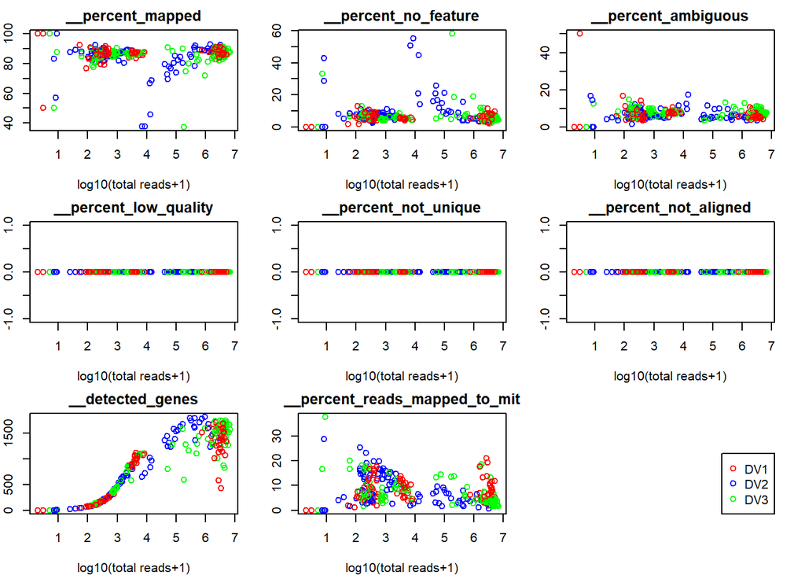

Figure 1. Quality statistics of samples

The quality of the dataset looks good, we have high percentages of mapped reads, not many genes mapped to mitochondrial genome and not many low quality reads.

We looked at olfactory neurons’ maturity markers to select samples based on neuron density.

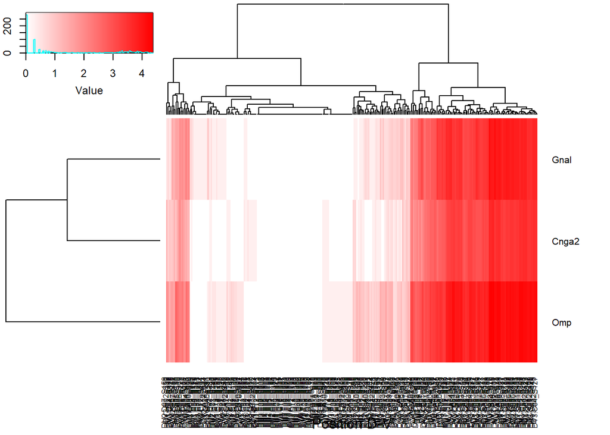

Figure 2. Neuronal markers expression heatmap.

Sample selection

We took the clusters with high expression of OSN markers (cluster [[1]][[1]] and cluster[[2]]) for our analysis

The statistics of our selected samples look as follows:

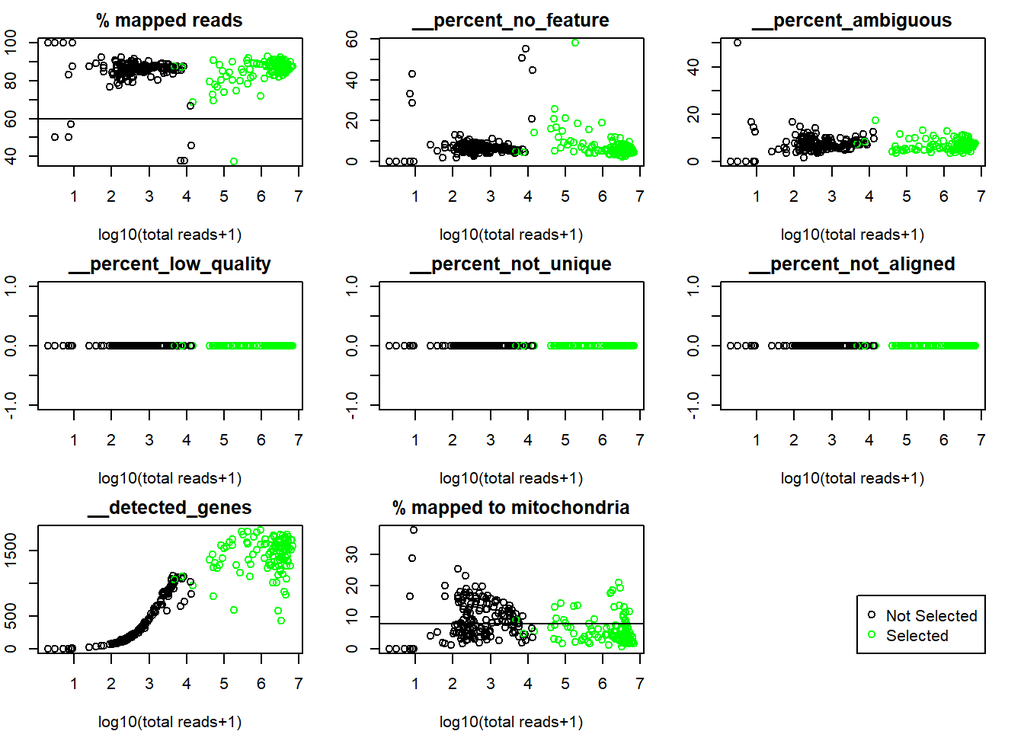

Figure 3. Quality statistics for not selected and selected samples.

Here we can see the distribution of quality statistics among our selected samples.

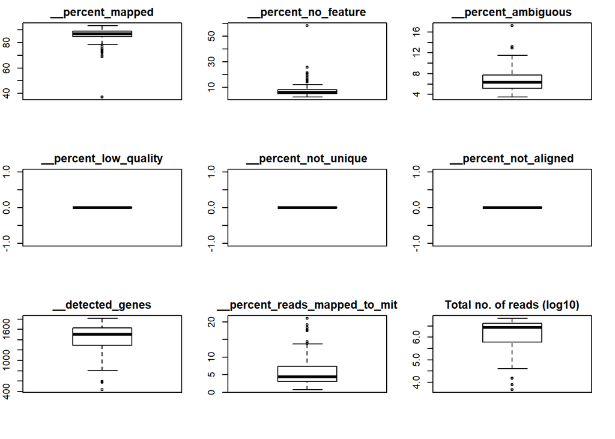

Figure 4. Stats of good samples

Then we plotted the number of Dorsal and ventral samples that we selected. As the most ventral samples can have a smaller amount of neurons because of the size of the slices, we can confirm that most of the samples we selected are from the dorsal area.

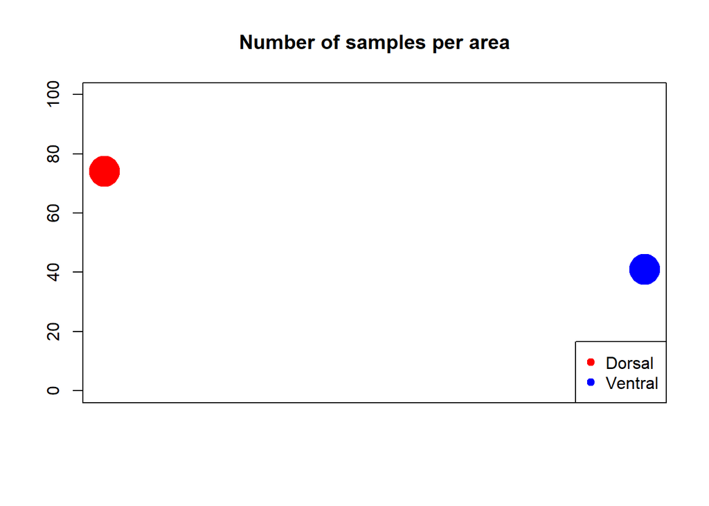

Figure 5. Number of dorsal (1-48) and ventral (49-96) samples selected

```
##        #Good    %Good #Bad     %Bad
## batch1    43 44.79167   53 55.20833
## batch2    26 27.08333   70 72.91667
## batch3    46 47.91667   50 52.08333
```

Table 1. Good (selected) and bad (not selected) samples per batch

Having eliminated the samples with low neuron density, we normalized our data using the DESeq method.

In order to see if the samples clustered in some way based on our expression data, we performed a principal components analysis.

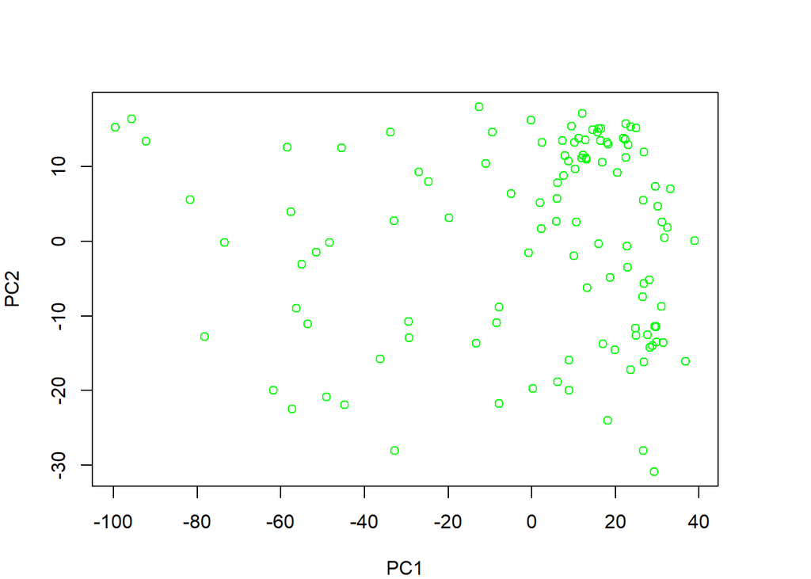

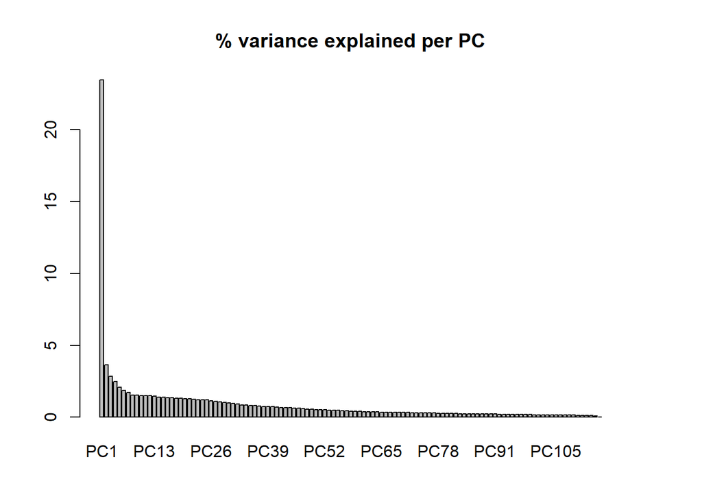

Figure 6. Selected samples’ expression PCA

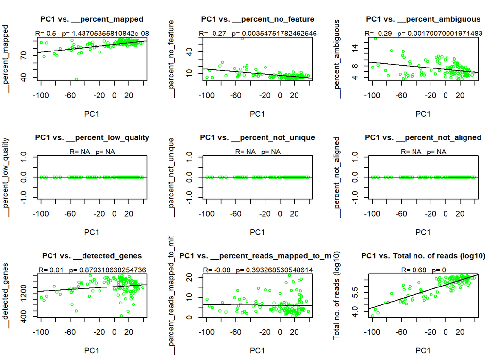

Figure 7. PC1 vs. quality

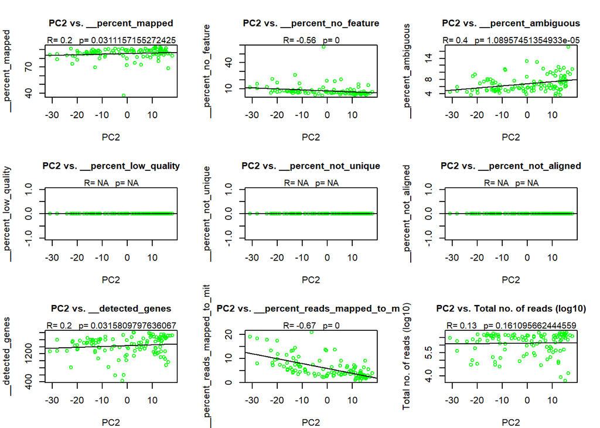

Figure 8. PC2 vs. quality

As we wanted to see if PC1 and PC2 were related with samples’ position in the MOE, we plotted PC1 vs. PC2 using a color gradient to see samples’ position (dorsal-ventral) in the MOE. Then we plotted each of these principal components vs our position indexes and performed Spearman correlation tests.

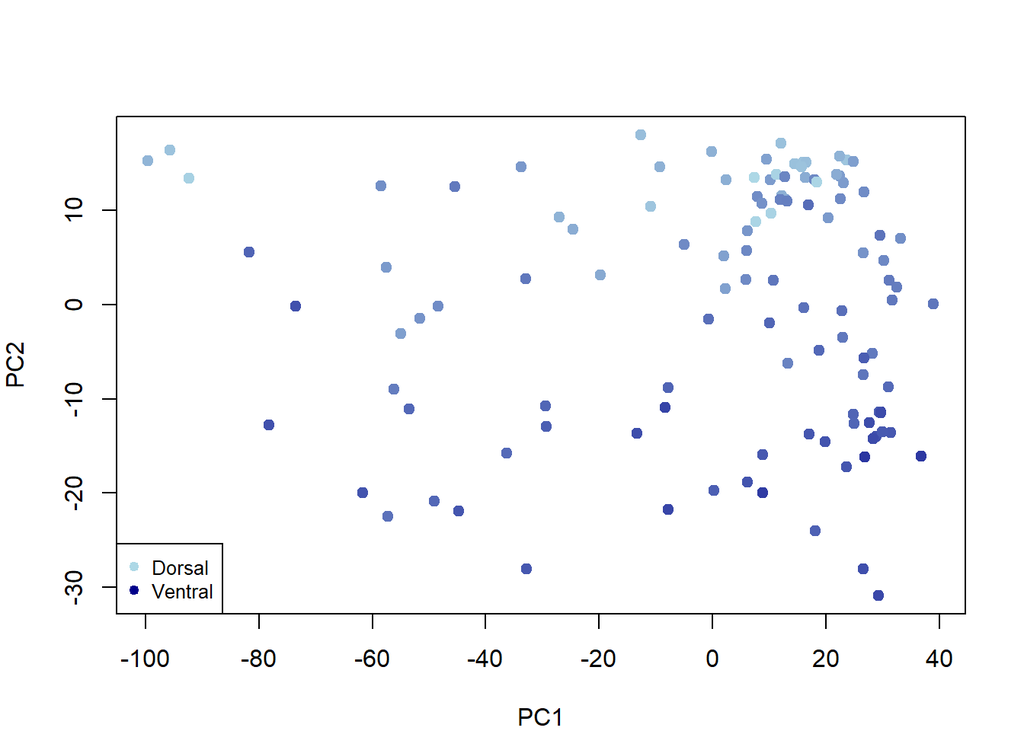

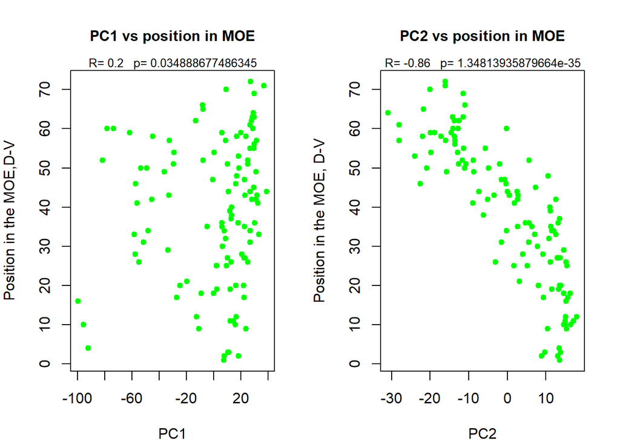

Figure 9. Pricipal components’ and samples’ positions in the MOE.

Differential expression across DV axis

In order to find differentially expressed genes across the DV axis, we scanned our gene expression counts getting the average expression of windows of 10 positions (samples) per gene; we took the minimum and the maximum values for each gene and used DESeq to test if the difference between these means was signifficant.

```r
#Average gene expression in windows of 10 positions

#order normalized by position
colnames(normalized)<-paste(sel_positions, colnames(normalized))
normalized<-rbind(normalized, sel_positions)
normalized<-normalized[,order(sel_positions)]

colnames(selected)<-paste(sel_positions, colnames(selected))
selected<-rbind(selected, sel_positions)
selected<-selected[,order(sel_positions)]

min_max<-data.frame(rep(0, 20))
min_max<-t(min_max)
means<-data.frame(rep(0, (dim(selected)[2]-9)))
means<-t(means)
namesmm<-data.frame(rep(0, 20))
namesmm<-t(namesmm)
y<-numeric()
z<-character()

for(i in 1:dim(selected)[1]){
  j<-sapply(1:(dim(selected)[2]-9), function(x){mean(selected[i, x:(x+9)])})
  y[1:10]<-selected[i, which(j==min(j))[1]:(which(j==min(j))[1]+9)]
  z[1:10]<-colnames(selected)[which(j==min(j))[1]:(which(j==min(j))[1]+9)]
  y[11:20]<-selected[i, which(j==max(j))[1]:(which(j==max(j))[1]+9)]
  z[11:20]<-colnames(selected)[which(j==max(j))[1]:(which(j==max(j))[1]+9)]
  min_max<-rbind(min_max, y)
  means<-rbind(means, j)
  namesmm<-rbind(namesmm, z)
}
min_max<-min_max[-1,]
colnames(min_max)<-c(paste("min", 1:10, sep=""), paste("max", 1:10, sep=""))
rownames(min_max)<-rownames(selected)

namesmm<-namesmm[-1,]
colnames(namesmm)<-c(paste("min", 1:10, sep=""), paste("max", 1:10, sep=""))
rownames(namesmm)<-rownames(selected)

means<-means[-1,]
rownames(means)<-rownames(selected)

group<-c(rep("min", 10), rep("max", 10))
coldata <- data.frame(row.names=colnames(min_max), group)
dds1 <- DESeqDataSetFromMatrix(countData=as.matrix(min_max), colData=coldata, design=~group) #transform dataset
dds1<-DESeq(dds1)
```

```
## -- replacing outliers and refitting for 5334 genes
## -- DESeq argument 'minReplicatesForReplace' = 7
## -- original counts are preserved in counts(dds)
```

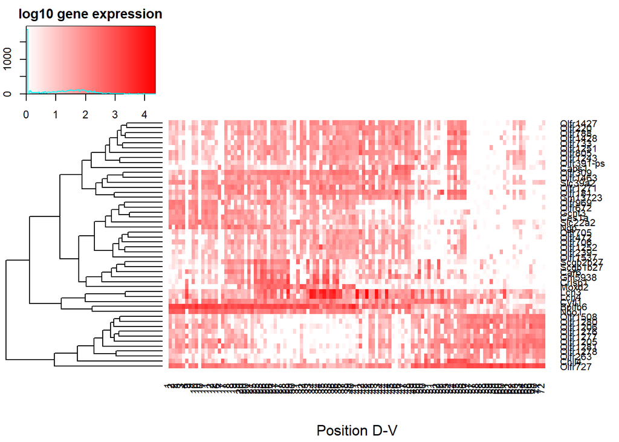

```r
res<-results(dds1)

resOrdered<-res[order(res$padj),]
#getwd()
#write.csv(resOrdered, "./diffexp_windows10.csv")
#heatmap(normalized[match(rownames(resOrdered)[1:50], rownames(normalized)),])
heatDEGs<-log10(normalized[match(rownames(resOrdered)[1:50], rownames(normalized)),]+1)
colnames(heatDEGs)<-normalized[dim(normalized)[1],]
heatmap.2(heatDEGs, Colv = NA, xlab="Position D-V", trace='none', key.title="log10 gene expression", key.ylab=NA, key.xlab=NA, col=my_palette, cexRow = 0.8, cexCol = 0.8)
```

Figure 10. Heatmap of expression of top 50 differentially expressed genes across the DV axis with dendrogram clustering genes with similar spatial expression patterns

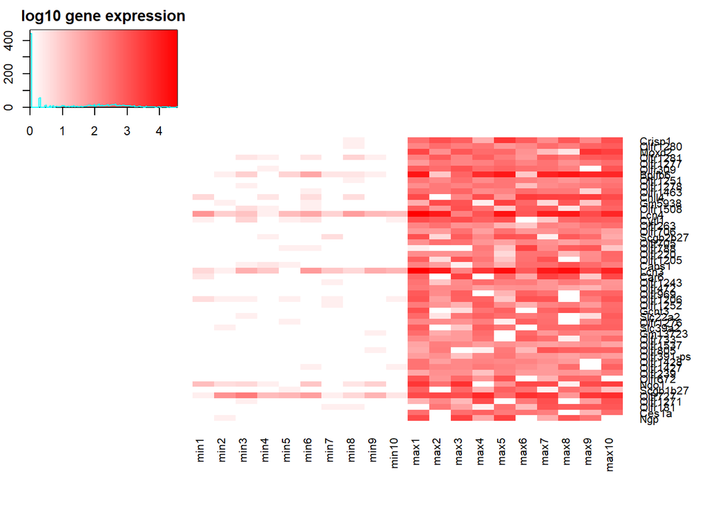

```r
heatDEGs1<-log10(min_max[match(rownames(resOrdered)[1:50], rownames(min_max)),]+1)
heatmap.2(heatDEGs1, Rowv = NA, Colv = NA, xlab="", dendrogram ='none', trace='none', key.title="log10 gene expression", key.ylab=NA, key.xlab=NA, col=my_palette, cexRow = 0.8, cexCol = 0.8)
```

Figure 11. Heatmap of expression of top 50 differentially expressed genes in the gene windows with the lowest and highest mean.

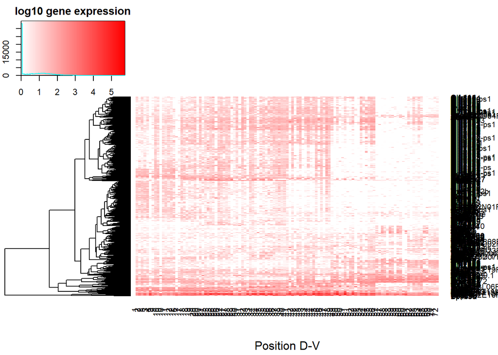

```r
heatDEGs2<-log10(normalized[match(rownames(resOrdered)[1:length(which(resOrdered$padj<0.05))], rownames(normalized)),]+1)
colnames(heatDEGs2)<-normalized[dim(normalized)[1],]
heatmap.2(heatDEGs2, Colv = NA, xlab="Position D-V", trace='none', key.title="log10 gene expression", key.ylab=NA, key.xlab=NA, col=my_palette, cexRow = 0.8, cexCol = 0.8)
```

Figure 12. Heatmap of all DEGs with dendrogram clustering genes with similar spatial expression patterns

```r
#ORs among DEGs

DEGs<-normalized[match(rownames(resOrdered)[1:length(which(resOrdered$padj<0.05))], rownames(normalized)),]
colnames(DEGs)<-normalized[dim(normalized)[1],]
#write.csv(DEGs, "./DEGs_expression.csv")

DEGs<-read.csv("./DEGs_expression.csv", header = TRUE, row.names = 1)
resOrdered<-read.csv("./diffexp_windows10.csv", header=TRUE, row.names=1)

library(VennDiagram)
```

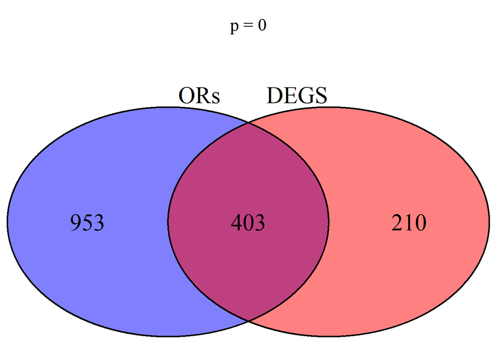

```r
ORs_DEGs_venn<-venn.diagram(list(DEGS=rownames(DEGs), ORs=rownames(resOrdered)[grep("Olfr", rownames(resOrdered))]), fill = c("red", "blue"), hyper.test = TRUE, total.population = 52637, lower.tail = FALSE, alpha = c(0.5, 0.5), cex = 2, cat.cex = 2, cat.pos = c(-10,10), sub.cex = 1.5, filename = NULL, scaled=F)

par(mfrow=c(1, 1), mar=c(4, 4, 4, 4))
grid.draw(ORs_DEGs_venn)
```

Figure 13. Venn diagram describing the amount of OR genes among the differentially expressed genes (DEGs)

```r
#Clustering
cor.degs<-cor(t(DEGs),method="spearman") #compute correlation matrix
test.dist<-as.dist(sqrt(0.5*((1-cor.degs)))) #define distance matrix


require(dynamicTreeCut)
require(WGCNA)
test.clust<-hclust(test.dist, method="average")
#estimate number of clusters with dynamicTreeCut
cut2<-cutreeDynamic(test.clust,distM=as.matrix(test.dist),
                    minClusterSize=30, method="hybrid",deepSplit = 1 )
```

```
##  ..cutHeight not given, setting it to 0.7  ===>  99% of the (truncated) height range in dendro.
##  ..done.
```

```r
clusters<-labels2colors(cut2)

names(clusters)<-row.names(DEGs)
table(clusters)
```

```
## clusters
##      blue     brown     green      grey       red turquoise    yellow
##       157       114        42         1        39       187        73
```

```r
#visualize data with tsne
require(Rtsne)
```

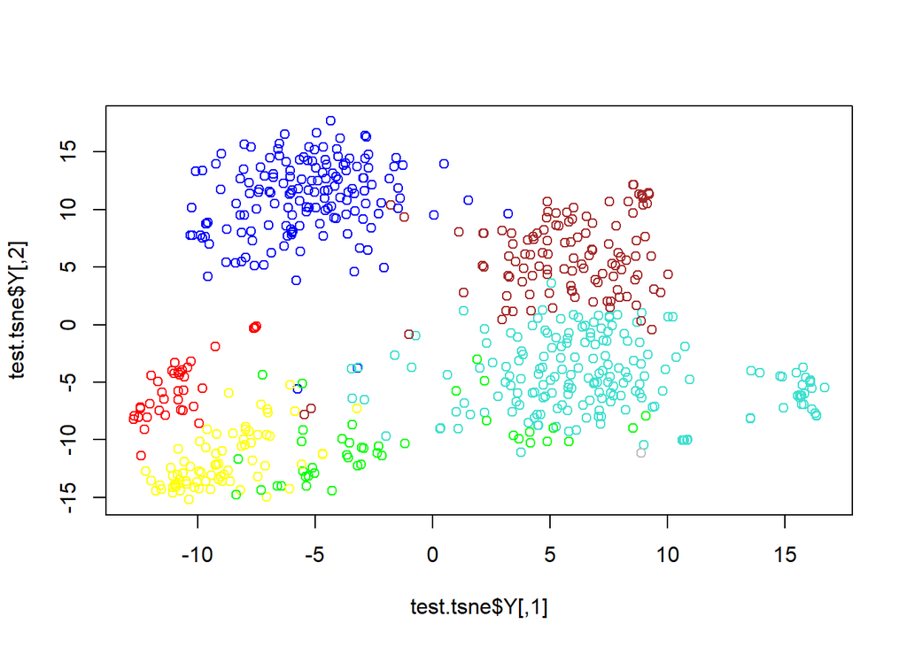

```r
set.seed(10)
test.tsne<-Rtsne(test.dist, is_distance = T)
plot(test.tsne$Y, col=clusters)
```

Figure 14. PCA-like plot of DEGs based on their expression pattern across the DV axis. Colors=Clusters

```r
#Genomic positions

genes_data<-read.csv("../interactions_enhancers_ORs/mm10_gene_coords.txt", stringsAsFactors = F, header=T)
genes_data$length<-genes_data$Gene.end..bp.-genes_data$Gene.start..bp.
genes_data<-genes_data[order(genes_data$Chromosome.scaffold.name),]

#Clusters by position in the genome

clust<-character()
for(j in unique(genes_data$Chromosome.scaffold.name)){
  sel<-which(genes_data$Chromosome.scaffold.name==j)
  genes_data[sel,]<-genes_data[sel,][order(genes_data[sel,]$Gene.start..bp.),]

  clust[sel[1]]<-paste(j, ".", 1, sep="")
  x<-1
  i<-2
  thr<-1000000
  while(i<=length(sel)){
    if(genes_data$Gene.start..bp.[sel[i]]<=genes_data$Gene.start..bp.[sel[i-1]]+thr){
      clust[sel[i]]<-paste(j, ".", x, sep="")
    } else{
      x<-x+1
      clust[sel[i]]<-paste(j, ".", x, sep="")
    }
    i<-i+1
  }
}

genes_data$gen_clust<-clust
```

```r
#Test if there is an association between genes' position in the genome and their spatial expresssion pattern
DEGs_data<-genes_data[match(rownames(DEGs), genes_data$Gene.name),]
DEGs_data$clusters<-clusters

tbl<-table(DEGs_data$gen_clust, DEGs_data$clusters)
chisq.test(tbl)
```

```
##
##  Pearson's Chi-squared test
##
## data:  tbl
## X-squared = 401.21, df = 168, p-value < 2.2e-16
```

To test if there was an association between genes’ spatial expression patterns across the DV axis and their positions in the genome, we ran a Chi-squared test using data from clustering by spatial expression pattern and clustering by genomic position. As the p-value resulting from this test is lower than 0.05, we can say there is an association between the property of being in the same genomic cluster and the property of being in the same expression pattern cluster.

```r
#Expression patterns per cluster

library(matrixStats)
position<-sub('\\..*', '', colnames(DEGs))
position<-as.numeric(gsub("X", "", position))
rm(x)
norm_degs<-log10(DEGs+1)
norm_degs<-apply(norm_degs, 1, function(x){(x-min(x))/(max(x)-min(x))})
norm_degs<-data.frame(position, norm_degs)
#norm_degs<-t(norm_degs)

library(locfit)
```

```
## locfit 1.5-9.1    2013-03-22
```

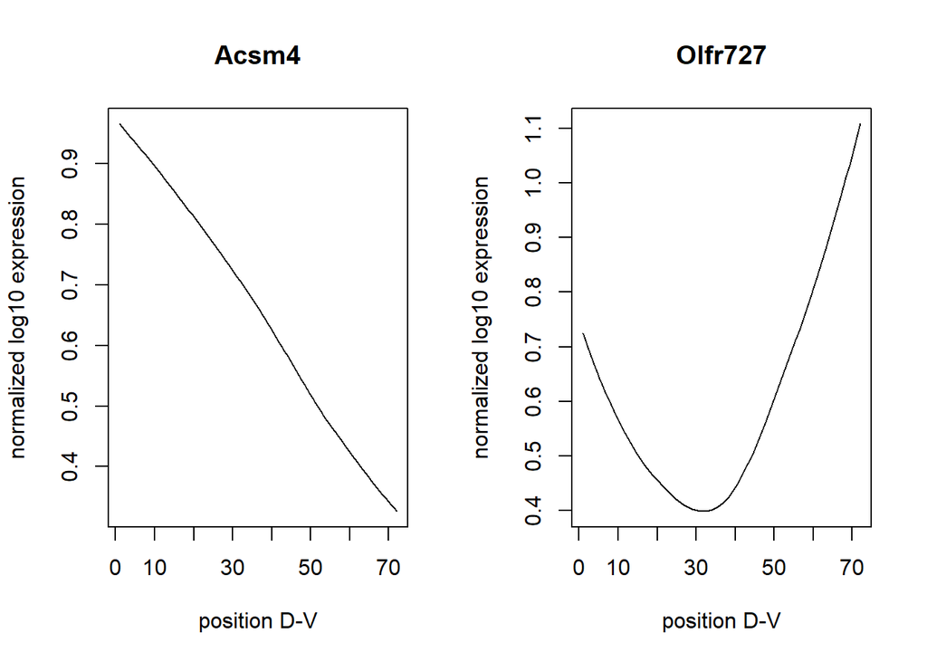

```r
par(mfrow=c(1, 2))

gene<-which(colnames(norm_degs)=="Acsm4")
plot(locfit(norm_degs[,gene]~lp(norm_degs[,1], deg = 2, nn=1), data=norm_degs), main="Acsm4", xlab="position D-V", ylab="normalized log10 expression")

gene<-which(colnames(norm_degs)=="Olfr727")
plot(locfit(norm_degs[,gene]~lp(norm_degs[,1], deg = 2, nn=1), data=norm_degs), main="Olfr727", xlab="position D-V", ylab="normalized log10 expression")
```

Figure 15. Spatial expression patterns of known genes with differential spatial expression. a) Acsm4, b) Olfr727

```r
fitted_data<-apply(norm_degs[,2:length(colnames(norm_degs))], 2, function(x){locfit(x~lp(norm_degs[,1], deg = 2, nn=1), data=norm_degs)})

std <- function(x) sd(x)/sqrt(length(x))

library(scales)
```

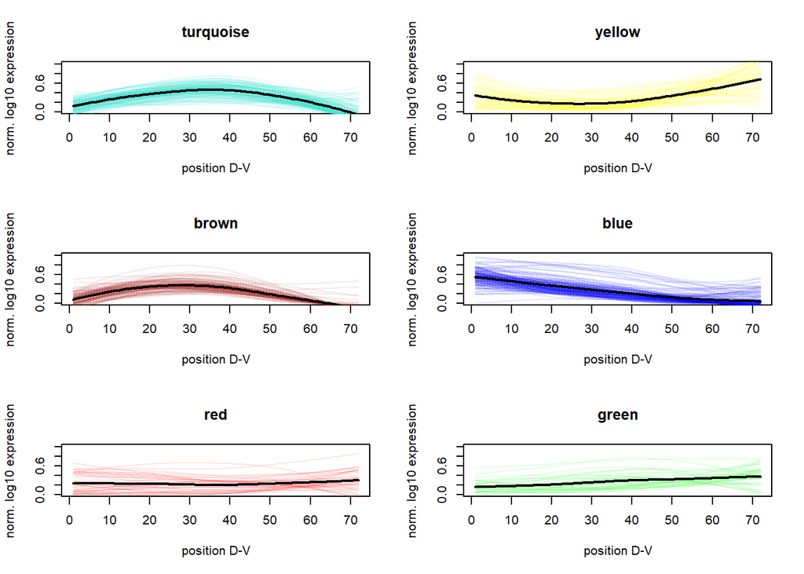

```r
par(mfrow=c(3, 2))


for(i in unique(clusters)[-length(unique(clusters))]){
  means<-rowMeans(norm_degs[,-1][,which(clusters==i)])
  plot(locfit(means~lp(norm_degs[,1], deg=2, nn=1)), ylim=c(0, 1), main=i, ylab="norm. log10 expression", xlab="position D-V")
#  plot(fitted_data[[ rownames(DEGs)[which(clusters==i)][1]]], ylim=c(0, 1), main=i, ylab="norm. log10 expression", type="l", col=i, xlab="position D-V")
  sapply(rownames(DEGs)[which(clusters==i)], function(x){lines(fitted_data[[x]], col=alpha(i, 0.1))})
  lines(locfit(means~lp(norm_degs[,1], deg=2, nn=1)), lwd=2)
}
```

```r
#for(i in unique(clusters)[-length(unique(clusters))]){
#  plot(position, colMeans(norm_degs[which(clusters==i),]), ylim=c(0, max(norm_degs)), main=i, ylab="norm. gene expression", type="l", col=i)
#  polygon(x=c(position, rev(position)), y=c(apply(norm_degs[which(clusters==i),], 2, function(y){mean(y)-std(y)}), rev(apply(norm_degs[which(clusters==i),], 2, function(y){mean(y)+std(y)}))), col=rgb(0.5, 0.6, 0.6, 0.2))
#}


#library(matrixStats)
#DEORs<-DEGs[grep("Olfr", rownames(DEGs)),]
#ORs_clusters<-DEGs_data$clusters[grep("Olfr", DEGs_data$Gene.name)]
#position<-sub('\\..*', '', colnames(DEORs))
#position<-as.numeric(gsub("X", "", position))
#rm(x)
```

Figure 16. Average gene expression per cluster across the DV axis and spatial expression pattern per gene in colors. Gene expression values were log10 scaled and then normalized to values between 0 and 1.

```r
#DEGs_pcomp<-prcomp(log10(DEGs+1), scale=F)
#plot(DEGs_pcomp$x[,1], DEGs_pcomp$x[,2], xlab="PC1", ylab="PC2", col=clusters)
#cor.test(DEGs_pcomp$x[,1], DEGs_data$Gene.start..bp., method="spearman")
```